# Lectura y escritura de datos e introducción a la programación de funciones en R

Julián Equihua

### ¿Qué aprendimos la clase pasada?

- Utilizar el operador **pipeline** para simplificar la aplicación de funciones de transformación de datos, una tras otra (recordar la tarea, ejercicio 3).
- Miscelánea de funcionalidades avanzadas de transformación de datos:
  - **joins** (uniones de dos o más tablas).
  - El paquete **tidyr** para transformar la **estructura** de los datos en una tabla.
- Un poco acerca de tipos de datos y datos faltantes (celdas vacías).
- Leer datos de CSV en R.

En esta clase aprenderemos a:

- Leer y escribir diversos objetos de R a formatos populares
- Cómo escribir funciones propias que lleven a cabo procesos complejos

### Lectura de datos

#### Detallando la interacción entre R y nuestro disco duro

En la clase pasada vimos que se puede cargar un archivo csv usando la función read_csv pertenecniente al paquete readr. La mecánica de lectura en R es sencilla y, sin importar el tipo de archivo que se quiera cargar a nuestro espacio de trabajo, siempre tiene la misma forma: se utiliza una función preparada para cargar un cierto tipo de archivo y luego se le debe indicar a R dónde está el archivo (de este tipo) que se desea cargar.

R tiene tiene una única manera de saber dónde buscar un archivo. Debe recibir una dirección que le indique dónde buscar físicamente el archivo de interés.

[figure not shown]

R puede “ver” lo que sea que le muestres, esto es, puedes decirle exáctamente dónde debe buscar un archivo, por ejemplo indicando con una cadena de texto una ruta completa en nuestro sistema de archivos (disco duro): “D:\repositories\intro-r\”. Estas rutas se pueden escribir manualmente, o se pueden copiar del explorador de archivos de nuestro sistema operativo y luego pegarla en R.

[figure not shown]

Es muy importante notar que en Windows, la convención es usar diagonales invertidas “\” para separar los niveles de nuestra ruta. R no va a entender que algo es una ruta si está construída con estos símbolos. Si se copia y pega una ruta desde nuestro explorador de archivos en Windows, debemos cambiar las diagonales invertidas por diagonales: “D:/repositories/intro-r/”.

Otra posibilidad, también ya mencionada, es indicarle a R que “vea” una carpeta de trabajo. En este momento R está “viendo” la siguiente carpeta:

```r
getwd()
```

```
## [1] "D:/repositories/intro-r/clases/5_lectura_escritura_funciones"
```

Estoy indica que R no necesita una ruta completa para leer cualquier cosa incluída en la carpeta anterior. Únicamente el archivo. Para cambiar la carpeta de trabajo se utiliza la funcón setwd() que como argumento escencial recibe una ruta. Por ejemplo:

```r
setwd("D:/repositories/")

getwd()
```

```
## [1] "D:/repositories"
```

Otra cosa que vale la pena mencionar es que RStudio incluye un explorador de archivos, ahí se puede navegar en las carpetas de nuestra computadora y con las opciones disponibles en el ícono de engrane se puede también asignar la carpeta de trabajo.

[figure not shown]

A veces resulta útil construir listas de los archivos que se encuentran en una ruta dada. R tiene funciones para llevar esto a cabo de manera automatizada. La función list.files() construye una lista de los archivos que se encuentran en una ruta argumento.

```
## [1] "clases"     "debug.log"  "ENCUESTA"   "imagenes"   "Readme.md"
## [6] "Readme.Rmd"
```

[output not shown]

Esta función tiene varios argumentos muy útiles que te permiten controlar cómo se llevará a cabo la búsqueda de archivos. Por ejemplo le puedes pedir a la función que exhaustivamente recorra todas las carpetas que se encuentran en la ruta argumento.

```
##  [1] "clases/1_intro_visualizacion/1_R_intro_visualizacion.Rmd"
##  [2] "clases/2_scripts/2_R_intro_scripts.nb.html"
##  [3] "clases/2_scripts/2_R_intro_scripts.Rmd"
##  [4] "clases/3_transformacion_datos/apuntes.Rmd"
##  [5] "clases/3_transformacion_datos/imagenes/campos_registros.jpg"
##  [6] "clases/4_transformacion_II_manejo_datos/anexos/anexo_lectura_bases_datos.Rmd"
##  [7] "clases/4_transformacion_II_manejo_datos/anexos/recordatorio_parte_I.Rmd"
##  [8] "clases/4_transformacion_II_manejo_datos/apuntes.html"
##  [9] "clases/4_transformacion_II_manejo_datos/apuntes.nb.html"
## [10] "clases/4_transformacion_II_manejo_datos/apuntes.Rmd"
## [11] "clases/4_transformacion_II_manejo_datos/datos/ataque_pokemon.csv"
## [12] "clases/4_transformacion_II_manejo_datos/datos/base_pokemon.sqlite"
## [13] "clases/4_transformacion_II_manejo_datos/datos/bd.png"
## [14] "clases/4_transformacion_II_manejo_datos/datos/defensa_pokemon.csv"
## [15] "clases/4_transformacion_II_manejo_datos/datos/velocidad_hp_pokemon.csv"
```

[output cut: 31 more lines]

O puedes pedir que sólo busque archivos de un cierto tipo (que terminen con una extensión dada)

```
## [1] "clases/1_intro_visualizacion/1_R_intro_visualizacion.Rmd"
## [2] "clases/2_scripts/2_R_intro_scripts.Rmd"
## [3] "clases/3_transformacion_datos/apuntes.Rmd"
## [4] "clases/4_transformacion_II_manejo_datos/anexos/anexo_lectura_bases_datos.Rmd"
## [5] "clases/4_transformacion_II_manejo_datos/anexos/recordatorio_parte_I.Rmd"
## [6] "clases/4_transformacion_II_manejo_datos/apuntes.Rmd"
## [7] "clases/5_lectura_escritura_funciones/5_R_lectura_escritura_funciones.Rmd"
## [8] "Readme.Rmd"
```

Lo que se incluye en el argumento pattern=“\.Rmd$” es una expresión regular y sirve para buscar patrones en cadenas de texto. Este tema escapa la intención de este curso pero para una introducción a él se puede consultar: http://stat545.com/block022_regular-expression.html.

Como sucede con el resultado de cualquier función, la salida de list.files() se puede asignar un objeto. Como ejercicio: generar una lista de archivos de cierto tipo a partir de una ruta en tu computadora y asignarla a un objeto en R. Probar qué sucede si se utilizan índices sobre esta lista, e.g. lista_archivos[1] y lista_archivos[1:3].

#### Lectura de diferentes tipos de archivos en R

En la clase pasada omitimos que existen numerosas variaciones de archivos de texto y csvs. Se utilizó la función read_csv() que lee archivos csv delimitados por comas:

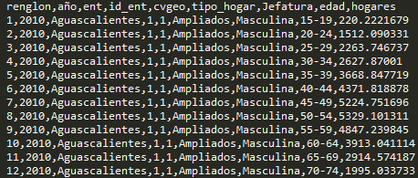

La mayoría de las funciones de readr tiene como objetivo convertir este tipo de archivos en data frames, aunque archivos de este tipo delimitados por comas es lo más común, nos podemos encontrar con archivos delimitados por otros símbolos, de aquí que existan las siguiente funciones:

- read_csv2() que lee archivos separados por punto y comas “;”
- read_tsv() lee archivos separados por Tabs
- read_delim() lee archivos separados por cualquier símbolo (tú lo determinas con un argumento)
- read_fwf() lee archivos de anchos fijos, se pueden especificar los anchos con fwf_widths() o su posición en el espacio (fila de datos) con fwf_positions().
- read_table() lee un caso muy particular y popular de lo anterior que son archivos con datos separados por un único espacio.

Como ya se mencionó, todas estas funciones tienen una sintaxtis similar. Lo más importante es alimentarles bien la ruta del archivo que se desea leer.

Aunque este tipos de archivos son extremadamente populares en el mundo de los archivos de datos, existen numerosas otras presentaciones. Por ejemplo, es muy común el uso de Microsoft Excel para análisis cuantitativo. R está bien preparado para leer y escribir archivos excel.

Bajaremos datos de Incidencia de Víctimas de homicidio, secuestro y extorsión de datos.gob.mx:

https://datos.gob.mx/busca/dataset/victimas-de-homicidio-secuestro-y-extorsion-excel

Para leer estos datos se utilizaremos el paquete readxl (no se les olvide instalarlo)

```r
# cargar el paquete
library("readxl")

# ¿dónde está el archivo? en mi caso:
mi_ruta <- "C:/Users/julco/Downloads/Datos_abiertos_Victimas_Fuero_comun.xls"

# leer este archivo
datos <- read_excel(mi_ruta,sheet=1)
```

Estos datos contienen conteos de delitos y sus modalidades por mes, para los estados de la república en los últimos cuatro años.

Estos se leen como un data.frame y todo lo aprendido sobre data.frames hasta ahora aplica al objeto datos. Podemos por ejemplo generar una nueva variable “total” haciendo con la función rowSums(). Esta suma por filas, las cantidades de las columnas elegidas. Antes de poder sumar debemos observar que las columnas donde se encuentran los conteos son de la 6 a la 17.

```r
# cargar el tidyverse
library("tidyverse")
datos <- mutate(datos, total = rowSums(datos[,6:17],na.rm=TRUE))
```

Ya que agregamos esta variable nueva, podemos concentrarnos en los Homicidios Dolosos y elegir sólo campos de nuestro interés.

```r
datos_homicidios  <- datos %>%
                    select(ENTIDAD,AÑO,DELITO,MODALIDAD,total)%>%
                    filter(MODALIDAD == "DOLOSO")
```

```r
ruta_escritura = "C:/Users/julco/Downloads/Datos_abiertos_Homicidios_Dolosos.csv"

write_csv(datos, path=ruta_escritura)
```

En general una búsqueda en google informa sobre cómo leer cualquier tipo de archivo en R.

[figure not shown]

Lo mismo para guardar archivos en nuestro formato de elección, por ejemplo imágenes. Para guardar los resultados de nuestros ejercicios de visualización de datos existen numerosas funciones. Por ejemplo para guardar fácilmente gráficas hechas con ggplot2 existe la función ggsave.

Ejercicio: Con el siguiente código de muestra generar una gráfica de barras a apiladas de homicidios dolosos por entidad.

ggplot(data = datos_homicidios, aes(x = reorder(ENTIDAD,total), y = total, fill = AÑO)) + geom_bar(stat = “identity”) + labs(y=“Homicidios dolosos”, x=“Entidad”) + coord_flip()

Luego utilizar la función ggsave para guardar la gráfica como un archivo PDF.

ggsave(“mi_ruta/mi_nombre_archivo.pdf”, width = 20, height = 20, units = “cm”)

Notar que nuevamente lo que es importante es indicarle a R una ruta apropiada (con el nombre del archivo y su extensión) para que sepa a dónde mandar nuestra gráfica.

### Funciones en R

Las funciones permiten la automatización de tareas. La escritura de funciones tiene tres grandes ventajas:

- Puedes nombrar una función de una manera tal que nunca olvides qué hace, esto además hace a tu código más legible
- Cuando cambien los requerimientos de los trabajos día a día, deberás de modificar menos código
- Se reduce la probabilidad de cometer errores llevando a cabo procesos manuales como copiar/pegar datos e instrucciones.

Aprender a escrbir buenas funciones es un proceso que nunca termina. Siempre se encontrarán maneras novedosas de mejorar estilos a la hora de escribir funciones. Esta sección no tiene como objetivo profundizar en la escritura de funciones, si no empezar a escribir funciones útiles lo más pronto posible.

#### ¿Cuándo me conviene escribir funciones?

Como regla de dedo, si notas que para llevar a cabo una cierta tarea en R estás copiando y pegando un bloque de código más de dos veces, es hora de escribir una función para ello.

Por ejemplo sabemos que para calcular el área de un círculo se puede utilizar siempre la misma fórmula. Lo único cambiante es el radio del círculo de interés. Si escribimos una función en R que permita llevar a cabo este cálculo podremos usarla en cualquier momento.

Como un primer ejemplo escribamos una función que permita calcular el área de un círculo.

#### Escribiendo funciones en R

Pasos para crear una función:

- Elegir un nombre apropiado
- Pensar en qué hace y cuántos argumentos necesita para ejecutarse
- Traducir lo que queremos que haga a código de R dentro de un bloque asociado a una función y a los argumentos anteriores

Pensando en estos pasos decidamos que nuestra función se llame area_circulo() (sin acento, es en general, mala práctica utilizar caractéres especiales en código). Luego sabemos que la función recibe un único parámetro, el radio del círculo al que se le va a calcular el área. Finalmente se debe plazmar la fórmula para el cálculo del área de un círculo en R.

```r
# nombre ------------- argumentos
area_circulo    <- function(radio)

# aquí inicia el cuerpo de la función
{

  # operamos sobre el radio del círculo
  area_calculada <- pi * radio^2

  # regresamos el resultado (esto es lo que se asigna después de aplicar esta función)
  return(area_calculada)

}
# aquí termina el cuerpo de la función


# probemos nuestra función para un círculo de tamaño 10 unidades
area_resultante <- area_circulo(radio=10)

area_resultante
```

```
## [1] 314.1593
```

Dentro de una función pueden colocarse cualquiera de los elementos que se han visto en las clases pasadas. Por ejemplo se pueden incluir expresiones condicionales e incluso se pueden incluir otras funciones.

Las expresiones condicionales tiene la forma

si { expresión } entonces

si no entonces

Esto es, checa si “expresión” es VERDADERA y si lo es, ejecuta el correspondiente bloque de código. Si expresión es falsa, ejecuta otro bloque de código o nada.

Por ejemplo, no tiene sentido pensar en radios de círculos de magnitud negativa. Para nuestra mala fortuna la fórmula del círculo elimina el efecto de un radio negativo y calcula una misma área para un radio independiéntemente si es positivo o negativo.

Aún así, como ejemplo, introduciremos una expresión condicional que permita “atrapar” radios negativos y que nos de un aviso de que algo anda raro cuando esto suceda.

```r
# nombre ------------- argumentos
area_circulo    <- function(radio)

# aquí inicia el cuerpo de la función
{
  # expresión condicional (si TRUE se ejecuta)
  if (radio<0)
  {
    print("No se permiten radios negativos")
  }
  # sigue la expresión condicional (esto se ejecuta cuando FALSE)
  else
  {
    # operamos sobre el radio del círculo
    area_calculada <- pi * radio^2

    # regresamos el resultado (esto es lo que se asigna después de aplicar esta función)
    return(area_calculada)
  }

}
# aquí termina el cuerpo de la función


# probemos nuestra función para un círculo de tamaño 10 unidades
area_resultante <- area_circulo(radio=-10)
```

```
## [1] "No se permiten radios negativos"
```

```r
area_resultante
```

```
## [1] "No se permiten radios negativos"
```

Ejercicio: escribir una función análoga a la anterio pero para clacular el área de un rectángulo. Tampoco debe permitir parámetros negativos.

Hint: recordar que expresiones condicionales se pueden agregar con las operaciones “y” en R “&” y “o” en R “|”.

#### un ejemplo más complejo y una introducción más formal a data.frames y tibbles

##### data.frames

Un data.frame se utiliza para almacenar tablas de datos. Es una lista de vectores de la misma longitud. Pueden ser de distintos tipos. Se puede pensar a los data.frames como las tablas de datos que se utilizan en excel. Siempre son matrices donde se accede a las celdas a través de coordenadas de la forma (rango de números para las filas , rango de letras para las columnas). En R se accede a las celdas utilizando las funciones vistas anteriormente y de manera más básica a través de coordenadas de la forma (rango de números para las filas , rango de números para las columnas).

Revisemos esto con base en un data.frame artificial que generaremos.

La segunda columna es simplemente un vector con valores booleanos.

La tercera tiene elementos texto que representan nombres.

```r
nuestro_df <- data.frame(

  # nombre de la columna --- # vector de datos
  normal_estandar = rnorm(5),
  booleano = c(TRUE,TRUE,FALSE,TRUE,FALSE),
  perritos = c("Pancho","Juana","Frijol","Fido","puppie")
)

View(nuestro_df)
```

Como se mencionó se puede acceder a las celdas de nuestro_df con coordenadas de la forma (rango de números para las filas , rango de números para las columnas).

Observación importante, en los data.frames las columnas se pueden elegir con números o con su nombre. Dejar una de las dimensiones de vacías indica que se elige todo lo disponible en esa dimensión.

Ejercicio: Ejecutar una por una las siguientes maneras de acceder a partes de nuestro_df y poner atención a cómo se comportan.

```r
# elegir el elemento de la primera fila y la primera columna de nuestro_df
nuestro_df[1,1]

# elegir los elementos de todas las filas y todas las columnas de nuestro_df
nuestro_df[,]

# elegir todos los elementos de la primer columna de nuestro_df
nuestro_df[,1]

# elegir todos los elementos de la primer columna de nuestro_df
nuestro_df[[1]]

# elegir todos los elementos de la primer columna de nuestro_df
nuestro_df[,"normal_estandar"]

# elegir todos los elementos de la primera y tercera columna de nuestro_df
nuestro_df[,c("normal_estandar","perritos")]

# elegir todos los elementos de la primera y tercera columna de nuestro_df
nuestro_df[,c(1,3)]

# elegir todos los elementos de la primera, segunda y tercera columna de nuestro_df
nuestro_df[,c(1,2,3)]

# elegir todos los elementos de la primera, segunda y tercera columna de nuestro_df
nuestro_df[,1:3]

# elegir todos los primeros 3 elementos de la primera, segunda y tercera columna de nuestro_df
nuestro_df[1:3,1:3]
```

Una vez que se elige una columna, esta se puede tratar como un vector. Como este tiene una sola dimensión entonces acceder a las celdas se hace teniendo esto en mente.

Por ejemplo, sobre el vector de nombres de perritos se puede hacer lo siguiente para obtener sólo los primeros tres nombres.

```r
# elegimos el vector de nombres de perritos y lo asignamos a un nuevo objeto

vector_perritos <- nuestro_df[,"perritos"]

# elegimos sólo los primeros tres nombres
vector_perritos[1:3]
```

```
## [1] Pancho Juana  Frijol
## Levels: Fido Frijol Juana Pancho puppie
```

Se observa que data.frame tiene como comportamiento default convertir vectores texto en variables categóricas, en R “factores”. Esto es un comportamiento hoy en día poco deseado y se evita colocando en la instrucción que genera el data.frame, esto es la función data.frame(), el parámetro stringsToFactors=FALSE.

Esto es tan poco popular que la versión más moderna de los data.frames, llamados tibbles (y que hemos venido usando), tiene esto apagado por default.

##### tibbles

Las “tibbles” simplemente son data.frames que han sido modificados para hacer nuestra vida, sobretodo utilizando el tidyverse, un poco más fácil.

Para convertir un data.frame en un tibble basta con utilizar la función (todo esto en realidad pertenece al paquete tibble)

as_tibble()

```r
library("tidyverse")

# convertimos nuestro_df a un tibble y lo asignamos al objeto nuestro_tibble
nuestro_tibble <- as_tibble(nuestro_df)

nuestro_tibble
```

```
## # A tibble: 5 x 3
##   normal_estandar booleano perritos
##             <dbl>    <lgl>   <fctr>
## 1     -0.30740182     TRUE   Pancho
## 2     -0.10694134     TRUE    Juana
## 3      1.68048645    FALSE   Frijol
## 4     -0.05278388     TRUE     Fido
## 5     -0.89302282    FALSE   puppie
```

Como se puede observar, algo default de un tibble es que a la hora de consultarlo indica la naturaleza de cada una de las columnas.

Para acceder a la información de las tibbles se recomienda utilizar las funciones que se han venido enseñando hasta la fecha (en las clasese de transformación y manipulación de datos).

Si se quiere acceder crudamente a las celdas de objetos tibble se puede utilizar sintaxis análoga a la vista en la subsección anterior pero usando un pipe y colocando un punto, llamado placeholder, antes del corte de nuestra tabla de datos.

```r
# elegir el elemento de la primera fila y la primera columna de nuestro_df
nuestro_df[1,1]
```

```
## [1] -0.3074018
```

```r
nuestro_tibble  %>% .[1,1]
```

```
## # A tibble: 1 x 1
##   normal_estandar
##             <dbl>
## 1      -0.3074018
```

```r
# elegir todos los elementos de la primer columna de nuestro_df
nuestro_df[[1]]
```

```
## [1] -0.30740182 -0.10694134  1.68048645 -0.05278388 -0.89302282
```

```r
nuestro_tibble  %>% .[[1]]
```

```
## [1] -0.30740182 -0.10694134  1.68048645 -0.05278388 -0.89302282
```

```r
# elegir todos los elementos de la primera, segunda y tercera columna de nuestro_df
nuestro_df[,1:3]
```

```
##   normal_estandar booleano perritos
## 1     -0.30740182     TRUE   Pancho
## 2     -0.10694134     TRUE    Juana
## 3      1.68048645    FALSE   Frijol
## 4     -0.05278388     TRUE     Fido
## 5     -0.89302282    FALSE   puppie
```

```r
nuestro_tibble  %>% .[,1:3]
```

```
## # A tibble: 5 x 3
##   normal_estandar booleano perritos
##             <dbl>    <lgl>   <fctr>
## 1     -0.30740182     TRUE   Pancho
## 2     -0.10694134     TRUE    Juana
## 3      1.68048645    FALSE   Frijol
## 4     -0.05278388     TRUE     Fido
## 5     -0.89302282    FALSE   puppie
```

```r
# elegir todos los primeros 3 elementos de la primera, segunda y tercera columna de nuestro_df
nuestro_df[1:3,1:3]
```

```
##   normal_estandar booleano perritos
## 1      -0.3074018     TRUE   Pancho
## 2      -0.1069413     TRUE    Juana
## 3       1.6804865    FALSE   Frijol
```

```r
nuestro_tibble  %>% .[1:3,1:3]
```

```
## # A tibble: 3 x 3
##   normal_estandar booleano perritos
##             <dbl>    <lgl>   <fctr>
## 1      -0.3074018     TRUE   Pancho
## 2      -0.1069413     TRUE    Juana
## 3       1.6804865    FALSE   Frijol
```

##### Un ejemplo más complejo de uso de funciones

Como un ejemplo más complejo de uso de funciones, generemos otrra tabla de datos artificial. Esto es un data.frame donde cada columna es el resultado de generar de manera aleatoria 10 números a partir de una distribución normal estándar.

```r
library("tidyverse")

df <- tibble(
  a = rnorm(10),
  b = rnorm(10),
  c = rnorm(10),
  d = rnorm(10)
)

df$a <- (df$a - min(df$a, na.rm = TRUE)) /
  (max(df$a, na.rm = TRUE) - min(df$a, na.rm = TRUE))
df$b <- (df$b - min(df$b, na.rm = TRUE)) /
  (max(df$b, na.rm = TRUE) - min(df$a, na.rm = TRUE))
df$c <- (df$c - min(df$c, na.rm = TRUE)) /
  (max(df$c, na.rm = TRUE) - min(df$c, na.rm = TRUE))
df$d <- (df$d - min(df$d, na.rm = TRUE)) /
  (max(df$d, na.rm = TRUE) - min(df$d, na.rm = TRUE))
```

¿Alguien puede decir qué proceso se llevó a cabo sobre cada una de las columnas? Más aún, existe un error en uno de los pasos de este proceso ¿alguien puede identificar cuál es?

Escribir una función que lleve a cabo este proceso para después aplicarlo a cada una de estas cuatro columnas es la mejor manera de evitar errores como el anterior.

Lo primero que se necesita para escribir una función es pensar en qué queremos que haga, seguido de pensar en cuántos argumentos requiere.

El proceso anterior actúa sobre una columna de nuestra tabla de datos y no requiere de nada más que una de estas columnas para llevarse a cabo.

Nosotros queremos escribir una función que escale un vector de datos (por ejemplo la columna de un data frame). Esto se logra restándole el mínimo y dividiendo entre el rango del mismo a cada una de sus entradas. Llamemos a la función “estandarizar”:

```r
# nombre ------------- argumentos
estandarizar    <- function(vector)

# aquí inicia el cuerpo de la función
{

  # operamos sobre el vector
  vector <- (vector - min(vector, na.rm = TRUE)) /
  (max(vector, na.rm = TRUE) - min(vector, na.rm = TRUE))

  # regresamos el resultado (esto es lo que se asigna después de aplicar esta función)
  return(vector)

}
# aquí termina el cuerpo de la función


# probemos nuestra función
a_estandarizada <- estandarizar(df$a)

a_estandarizada
```

```
##  [1] 0.7893338 0.3728318 0.0000000 0.3822105 0.9396178 1.0000000 0.9608185
##  [8] 0.7887629 0.3020458 0.6260430
```

Recordando que dentro de una función pueden colocarse cualquiera de los elementos que se han visto en las clases pasadas. Por ejemplo expresiones condicionales, vamos a incluir en la función anterior código que cheque si el vector que se va a estandarizar, lo está ya, para no realizar la operación de nuevo si no se necesita.

```r
library("tidyverse")

df <- tibble(
  a = rnorm(10),
  b = rnorm(10),
  c = rnorm(10),
  d = rnorm(10)
)

# nombre ------------- argumentos
estandarizar_check    <- function(vector)

# aquí inicia el cuerpo de la función
{

  # expresión condicional: ¿ya está entre 0 y 1 el vector de entrada?

  if (0<=min(vector) & max(vector)<=1)
  {
    # avísame si ya está estandarizado
    print("Ya está estandarizado, no hice nada")
  }
  else
  {
    # avísame si no lo está
    print("No está estandrizado, lo estandarizo")

    # operamos sobre el vector
    vector <- (vector - min(vector, na.rm = TRUE)) /
    (max(vector, na.rm = TRUE) - min(vector, na.rm = TRUE))

  }

  # regresamos el resultado (esto es lo que se asigna después de aplicar esta función)
  return(vector)
}
# aquí termina el cuerpo de la función


# probemos nuestra función
a_estandarizada <- estandarizar_check(df$a)
```

```
## [1] "No está estandrizado, lo estandarizo"
```

```r
a_estandarizada <- estandarizar_check(a_estandarizada)
```

```
## [1] "Ya está estandarizado, no hice nada"
```

Ahora que ya tengo una función que hace lo que quiero, puedo ejecutar de manera más sucinta y con menos posibilidad de errores lo que quería en un principio, que era estandarizar cada columna de nuestro data frame (df).

```r
df$a <- estandarizar_check(df$a)
```

```
## [1] "No está estandrizado, lo estandarizo"
```

### Iteración en R

En la sección anterior se vió cómo evitar duplicar código que se usa de manera recurrente utilizando funciones. Una función abstrae una tarea y permite llevarla a cabo sin escribir código adicional, sólo necesitando ciertos parámetros de entrada.

Otra herramienta útil para evitar escribir más código son los mecanismos de iteración. Estos son útiles cuando se quiere llevar a cabo la misma tarea múltiples veces.

En esta clase aprenderemos sobre dos paradigmas de iteración: la programación imperativa y la programación funcional.

La primera es un paradigma más antiguo y permite introducirse fácilmente al tema pues hace que la iteración sea muy explícita. Como desventaja, las estructuras de este paradigma, llamados bucles (en inglés loops), tienden a ser verbosos. La programación funcional ofrece herramientas para extraer todo el código duplicado para que cada bucle tenga su propia función. Después de un poco de práctica se puede resolver los problemas más comunes en iteración de manera más sencilla, utilizando menos código y por lo mismo cometiendo menos errores.

#### Programación imperativa

Un bucle está compuesto de una secuencia y un cuerpo que se ejecuta con base en esta secuencia.

Una secuencia:

```r
1:5
```

```
## [1] 1 2 3 4 5
```

Un bucle for puede ejecutar el mismo código (el contenido en su cuerpo) variando un iterador. Por ejemplo el siguiente código nos muestra uno por uno los números en la secuencia misma y en cada una de esas iteraciones nos muestra la palabra “gatito”.

```r
for (i in 1:5) # para la secuancia del 1 al 10
{
  print(i)
  print("gatito") # ejecutar esto
}
```

```
## [1] 1
## [1] "gatito"
## [1] 2
## [1] "gatito"
## [1] 3
## [1] "gatito"
## [1] 4
## [1] "gatito"
## [1] 5
## [1] "gatito"
```

Ejercicio: Escribir una función que calcule la media de cada columna de la tabla de datos de coches usada en clases pasadas.

mtcars

Hint: select() se puede aplicar sobre índices que indican la posición de la columna en la tabla de datos, e.g.

primera_columna <- datos %>% select(1)

O se puede utilizar lo visto en la sección anterior.

Un ejemplo juntando todo

Usando la función que extrae los datos de homicidios dolosos para un año y un bucle generaremos una gráfica de barras por año.

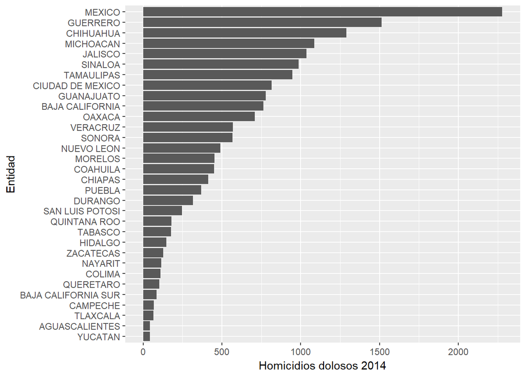

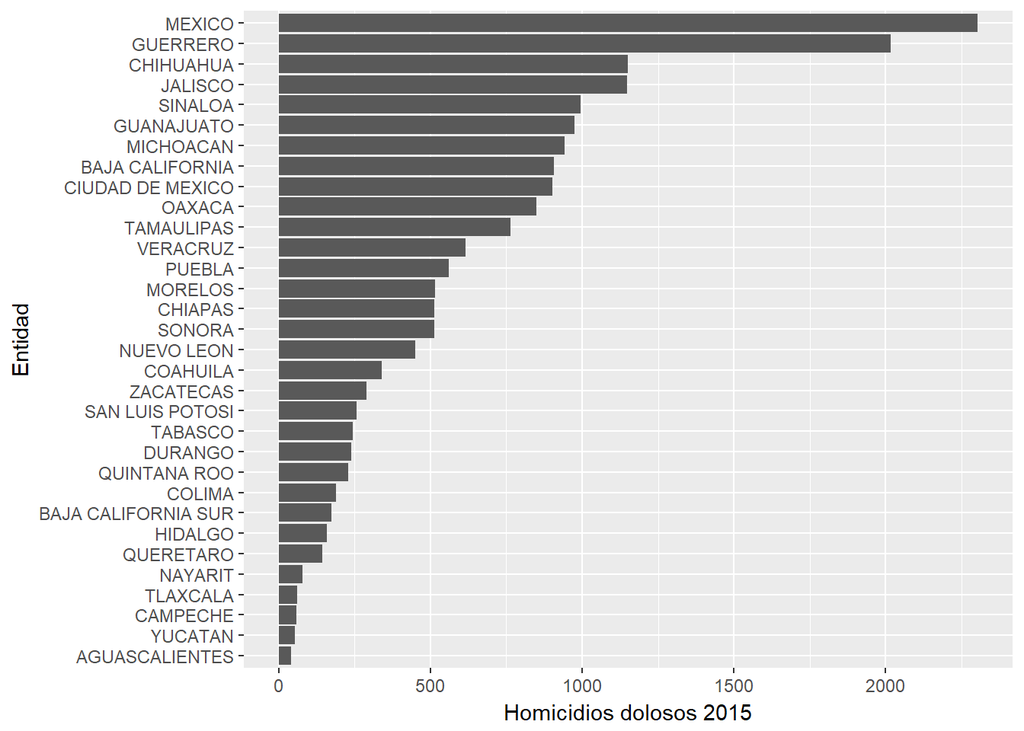

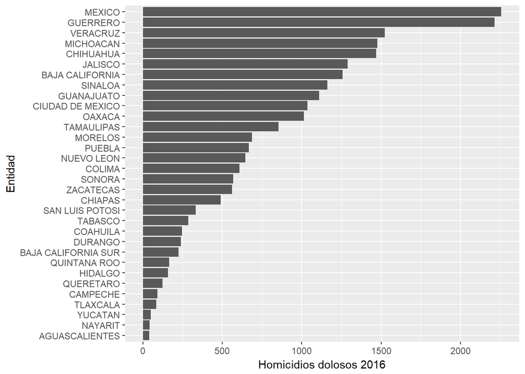

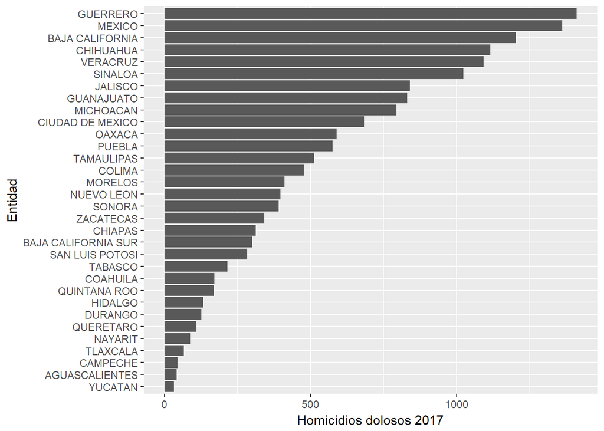

```r
extrae_homicidios_fecha <- function(datos,fecha)
{
  datos <- datos %>%
  select(ENTIDAD,AÑO,DELITO,MODALIDAD,total)%>%
  filter(MODALIDAD == "DOLOSO",AÑO==fecha)

  return(datos)
}

# bucle
for (i in 2014:2017)
{

  homicidios_anio <- extrae_homicidios_fecha(datos,i)

  homicidios_fecha <- paste0("Homicidios dolosos ",toString(i))

  print(ggplot(data = homicidios_anio, aes(x = reorder(ENTIDAD,total), y = total)) +
    geom_bar(stat = "identity") + labs(y=homicidios_fecha, x="Entidad") + coord_flip())
}
```

Ejercicio: Modificar el código anterior para que guarde un PDF para cada gráfica generada en la ruta de su elección.

#### Programación funcional

Ya se introdujo la idea de que se puede utilizar una función dentro de otra función. En esta sección se aprenderá a utilizar el paquete purr, que elimina la necesidad de aprender a generar bucles complejos. La base de R tiene funciones con la misma idea (apply(), lapply(), tapply(), etc) pero purr tiende a ser más consistente y por lo tanto más fácil de aprender a usar.

Si se quiere indagar en las funcones apply se puede consultar esta liga:

https://www.datacamp.com/community/tutorials/r-tutorial-apply-family#gs.bJ=BAKY

El objetivo de las funciones de purr es ayudar a romper las tareas de manipulación de listas en pedazos independientes:

Primero se debe plantear la interrogante ¿Cómo se puede resolver el problema de interés para un único elemento de la lista? Luego purr ayuda a generalizarlo a cada elemento de la lista.

##### La función map

La tarea de barrer un vector, hacer algo a cada elemento y luego guardar los resultados es tan común que el paquete purr provee una familia de funciones para llevar esto a cabo.

Existe una función para cada tipo de salida:

- map() genera una lista.
- map_lgl() genera un vector de valores lógicos.
- map_int() genera un vector de valores enteros.
- map_dbl() genera un vector de valores dobles (números reales).
- map_chr() genera un vector de valores texto.

Cada una de estas funciones recibe como entrada un vector, aplica una función elegida por el usuario a cada pedazo y regresa un vector de la misma longitud que el original (y con los mismos nombres).

Por ejemplo para calcular la media de cada columna de la tabla de datos de coches basta con hacer

```r
map_dbl(mtcars, mean)
```

```
##        mpg        cyl       disp         hp       drat         wt
##  20.090625   6.187500 230.721875 146.687500   3.596563   3.217250
##       qsec         vs         am       gear       carb
##  17.848750   0.437500   0.406250   3.687500   2.812500
```

##### La función walk

Es una alternativa a map cuando se quiere llamar una función más por sus efectos que por sus resultados. Esto es, sirve para llevar a cabo un proceso a lo largo de, por ejemplo, un vector.

Un ejemplo muy simple

```r
x <- list(1, "a", 3)

x %>%
  walk(print)  # si se fijan hace algo muy parecito a nuestro primer ejemplo de bucle
```

```
## [1] 1
## [1] "a"
## [1] 3
```

Las funciones map() y walk() iteran sobre múltiples arugmentos en paralelo, map2() y walk2() se especializan en el caso particular de 2 argumentos y pmap() y pwalk() en el caso de un número ilimitado de argumentos en una lista.

La función walk, en general, no es tan útil como las funciones walk2() or pwalk(). Por ejemplo para replicar el ejercicio de separar la tabla de datos de homicidios se puede usar map() seguido de pwalk() para además guardar los plots como pdf.

```r
plots <- datos_homicidios %>%
         split(.$AÑO) %>%

          # nota importante: "." al usar map sirve para algo análogo a "i" en los bucles

         map(~ggplot(data = ., aes(x = reorder(ENTIDAD,total), y = total)) +
            geom_bar(stat = "identity") + labs(y=homicidios_fecha, x="Entidad") + coord_flip())

paths <- stringr::str_c(names(plots), ".pdf")

pwalk(list(paths, plots), ggsave, path = getwd())
getwd()
```

```
## [1] "D:/repositories/intro-r/clases/5_lectura_escritura_funciones"
```

Tarea: desarrollar un script que incluya una función que lleve a cabo un proceso que generalmente llevarías a cabo usando otra herramienta, por ejemplo excel, sobre una tabla de datos propia. Explicar lo que se llevó a cabo.